# 画像のボケの分析の内容理解

## 画像のボケを計算するサンプルプログラムを調査する

`cv2.Laplacian()`関数を調べてみる

OpenCVチュートリアルを調べていくとLaplacian関数は傾き検出プログラムで利用されていることがわかった

https://docs.opencv.org/4.0.0/d5/d0f/tutorial_py_gradients.html

lecture07_ImageGradients.py

```python
#!/usr/bin/env python
# -*- coding: utf-8 -*-

import numpy as np
import cv2
import matplotlib.pyplot as plt
img = cv2.imread('uchitane_far.png',cv2.IMREAD_GRAYSCALE)
laplacian = cv2.Laplacian(img,cv2.CV_64F)
#print(laplacian[0:8,0:8])
sobelx = cv2.Sobel(img,cv2.CV_64F,1,0,ksize=5)
sobely = cv2.Sobel(img,cv2.CV_64F,0,1,ksize=5)
plt.subplot(2,2,1),plt.imshow(img,cmap = 'gray')
plt.title('Original'), plt.xticks([]), plt.yticks([])
plt.subplot(2,2,2),plt.imshow(laplacian,cmap = 'gray')
plt.title('Laplacian'), plt.xticks([]), plt.yticks([])
plt.subplot(2,2,3),plt.imshow(sobelx,cmap = 'gray')
plt.title('Sobel X'), plt.xticks([]), plt.yticks([])
plt.subplot(2,2,4),plt.imshow(sobely,cmap = 'gray')
plt.title('Sobel Y'), plt.xticks([]), plt.yticks([])
plt.show()
```

## 実行結果

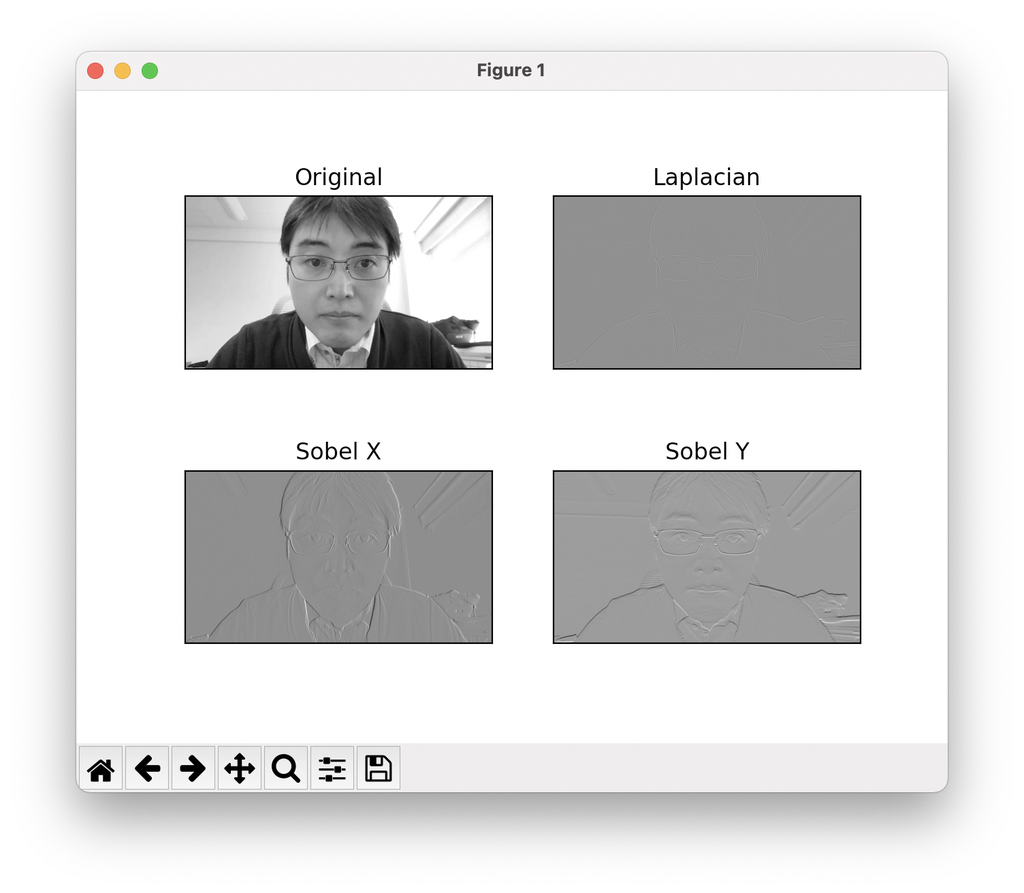

## 解説

laplacianの解説がチュートリアルのリンク先にかかれている

また，資料02_OpenCV_blurry_analysis.htmlの`var()`関数はnumpyモジュールに含まれる分散を計算する関数のことであった（調べてわかったことにしましょう）

ということは背景画像をただ単に消すだけでなくエッジだけ残して表示すれば，Zoomの背景効果のように背景画像を加工できるのではないだろうか

さらに資料03_OpenCV_BackgroundSubtruction.htmlで行っていた動きのある部分だけ残すという処理が使えそうなので，次は動きのある部分を残す処理について調べていくことにする

さらに資料03ということは，画像を区分（例えば32x32や16x16の領域でグリッド状に分ける）して，区分ごとのボケ（エッジが含まれるか）を調べることができるのではないだろうか

そしてPCのカメラで撮影した動画も区域ごとにボケ（エッジ）が含まれるか否かを計算すればZoomやTeamsの背景フィルターのようなものが作れるのではないだろうか？と思いついたとしよう

## まとめ

OpenCVのチュートリアルでLaplacian関数について調べたところアプリを作る発想を得た

ビデオ会議での背景画像を消す処理を作るために，次は動画で必要な領域（区分）だけを残す処理を考えていく